# Block 5: Folgt die MODIS-Grünfärbung der Produktivität?

Author

Anna-Katharina Koehn

Published

November 26, 2026

```r
library(readr)
library(dplyr)
library(tidyr)
library(ggplot2)
library(knitr)

daily <- read_csv("../data/processed/site_daily.csv", show_col_types = FALSE)
static <- read_csv("../data/processed/site_static.csv", show_col_types = FALSE)

site_names <- c("AU-Wom" = "Wombat", "JP-Fjy" = "Fujiyoshida",
                "SN-Dhr" = "Dahra", "US-Mo1" = "Missouri", "DE-Hte" = "Hütelmoor")

daily <- daily |>
  mutate(site_label = recode(site_id, !!!site_names))
```

## E1. Frage und Hypothese

**Frage:** Folgen EVI und NDVI bei meinen fünf FLUXNET-Türmen dem saisonalen Verlauf der brutto-primären Produktivität (GPP), und an welchen Standorten bzw. Jahreszeiten ist die Übereinstimmung am stärksten oder schwächsten?

**Hypothese:** Ich erwarte eine positive Beziehung zwischen GPP und beiden Vegetationsindizes, weil höhere Blattflächen und Photosyntheseaktivität in der Regel mit stärkerem grünen Reflektanzsignal einsteigen. Die Beziehung dürfte bei dem Dauersümmerwald AU-Wom, der Nadelwald-Standort JP-Fjy und der europäische Feuchtstandort DE-Hte deutlicher sein als bei der saisonal stark begrenzten Grasslandschaft SN-Dhr und der bewirtschafteten Fläche US-Mo1, weil Bewässerung, Ernte oder fehlende Blattbedeckung das spektrale Signal vom ökosystemweiten Kohlenstofffluss entkoppeln können.

Die fünf Türme bilden unterschiedliche Vegetationsformen und Kontinente ab und eignen sich daher für einen Vergleich verschiedener saisonaler Systeme. Mit nur fünf Standorten bleibt die Aussage jedoch exemplarisch, nicht repräsentativ für alle Ökosysteme.

## E2. Daten

```r
provenance <- tribble(
  ~Dataset, ~Variablen, ~Raumauflösung, ~Zeitauflösung_und_Perioden, ~Downloaded_on, ~Script_and_changes, ~Citation,
  "FLUXNET2015/ONEFlux", "GPP_NT_VUT_REF, NEE_VUT_REF_QC, TA_F", "Tower footprint (~100 m–1 km)", "Täglich, Turmzeitraum 2001–2025", "vor Block 5", "data/raw; bestehende FLUXMET_DD-Zips", "Pastorello et al. (2020), Scientific Data 7, 225; Einzelstandort-Citationen siehe snapshot",
  "MODIS MOD13Q1", "rot, NIR, blau; berechnetes NDVI und EVI; Pixel-Reliabilität", "250 m, 9×9-Pixel-Fenster", "16 Tage; letzte 3 Jahre je Turm", "November 2026", "08_modis_ndvi_evi.R; km = 1, years_back = 3, Reliability 0–1", "Didan (2021), MOD13Q1 V061, NASA LP DAAC, doi:10.5067/MODIS/MOD13Q1.061",
  "ERA5-Land", "2-m-Temperatur, 0–7 cm Bodentemperatur", "0.1° (~9 km), Punkt am nächsten Gitterpunkt", "stündlich und täglich; bis zu 10 Jahre je Turm", "November 2026", "01_era5land.R; Standardvariablen, 10 Jahre", "Muñoz-Sabater et al. (2021), Earth System Science Data 13, 4349–4383"
)

kable(provenance, caption = "Provenance der für den Report verwendeten Daten")
```

Provenance der für den Report verwendeten Daten

| Dataset | Variablen | Raumauflösung | Zeitauflösung_und_Perioden | Downloaded_on | Script_and_changes | Citation |
| --- | --- | --- | --- | --- | --- | --- |
| FLUXNET2015/ONEFlux | GPP_NT_VUT_REF, NEE_VUT_REF_QC, TA_F | Tower footprint (~100 m–1 km) | Täglich, Turmzeitraum 2001–2025 | vor Block 5 | data/raw; bestehende FLUXMET_DD-Zips | Pastorello et al. (2020), Scientific Data 7, 225; Einzelstandort-Citationen siehe snapshot |
| MODIS MOD13Q1 | rot, NIR, blau; berechnetes NDVI und EVI; Pixel-Reliabilität | 250 m, 9×9-Pixel-Fenster | 16 Tage; letzte 3 Jahre je Turm | November 2026 | 08_modis_ndvi_evi.R; km = 1, years_back = 3, Reliability 0–1 | Didan (2021), MOD13Q1 V061, NASA LP DAAC, doi:10.5067/MODIS/MOD13Q1.061 |
| ERA5-Land | 2-m-Temperatur, 0–7 cm Bodentemperatur | 0.1° (~9 km), Punkt am nächsten Gitterpunkt | stündlich und täglich; bis zu 10 Jahre je Turm | November 2026 | 01_era5land.R; Standardvariablen, 10 Jahre | Muñoz-Sabater et al. (2021), Earth System Science Data 13, 4349–4383 |

Das MODIS-Skript lädt ein Fenster von 9 × 9 Pixeln (etwa 2 × 2 km) und behält nur Pixels mit Pixel-Reliabilität 0 oder 1. NDVI und EVI werden aus den skalierten roten, Nahinfrarot- und blauen Bändern selbst berechnet. Der tägliche FLUXNET-Tableau wird mit dem 16-Tage-MODIS-Verlauf durch lineare Interpolation verbunden.

```r
modis_summary <- daily |>
  filter(is.finite(ndvi), is.finite(evi)) |>
  group_by(site_id, site_label) |>
  summarise(MODIS_days = n(),
            mean_ndvi = mean(ndvi, na.rm = TRUE),
            mean_evi = mean(evi, na.rm = TRUE),
            mean_GPP = mean(GPP_NT_VUT_REF, na.rm = TRUE),
            mean_ERA5_temperature_C = mean(era5l_t2m_C, na.rm = TRUE),
            .groups = "drop")

kable(modis_summary, digits = 3,
      caption = "Mittlere MODIS-Indizes und GPP an den fünf Türmen",
      col.names = c("Site", "Name", "N tägliche Werte", "Mittleres NDVI", "Mittleres EVI", "Mittlere GPP", "ERA5-Land Temp. (°C)"))
```

Mittlere MODIS-Indizes und GPP an den fünf Türmen

| Site | Name | N tägliche Werte | Mittleres NDVI | Mittleres EVI | Mittlere GPP | ERA5-Land Temp. (°C) |
| --- | --- | --- | --- | --- | --- | --- |
| AU-Wom | Wombat | 1084 | 0.787 | 0.401 | 7.285 | 11.840 |
| DE-Hte | Hütelmoor | 1084 | 0.643 | 0.330 | 2.477 | 10.110 |
| JP-Fjy | Fujiyoshida | 1084 | 0.682 | 0.347 | 5.247 | 9.925 |
| SN-Dhr | Dahra | 1084 | 0.321 | 0.239 | 2.354 | 28.525 |
| US-Mo1 | Missouri | 1083 | 0.481 | 0.341 | 5.216 | 13.757 |

## E3. Methoden

**Download:** Für MODIS wurde `08_modis_ndvi_evi.R` mit `years_back <- 3` und `km <- 1` ausgeführt. Damit wurden die letzten drei verfügbaren Jahre je Turm im Fenster von 9 × 9 MODIS-Pixeln heruntergeladen. Für ERA5-Land wurde `01_era5land.R` mit den Standardvariablen 2-m-Temperatur, Bodentemperatur und den Bodenschicht-Wasservariablen ausgeführt. Die tägliche Tabelle wurde danach mit `09_merge.R` erzeugt.

**Extraktion:** Die Turmkoordinaten wurden in WGS84 an MODIS und ERA5-Land übergeben. MODIS nutzt den nächstgelegenen Punkt und ein Quadrat um den Turm, ERA5-Land liefert den nächstgelegenen 0.1°-Gitterpunkt. FLUXNET-Werte wurden direkt über die gemeinsame `site_id` und das Datum verknüpft.

**Verarbeitung:** Fehlende Werte waren bereits `NA` bzw. wurden aus den FLUXNET-DD-CSV-Dateien als `-9999` gelesen. Der MODIS-Verlauf wurde pro Turm in der Tabelle linear auf tägliche Werte interpoliert. Für GPP wurde kein zusätzlicher Qualitätsfilter angewendet, da die Variable GPP_NT_VUT_REF bereits aus dem FLUXNET-Produkt stammt. Für MODIS wurden nur Pixel-Reliabilität 0–1 zugelassen. Für einen vergleichbaren saisonalen Blick wurden aus dem täglichen Tablea monatliche Mittel gebildet.

**Analyse:** Die Zusammenfassung basiert auf den mit GPP und EVI gemeinsamen monatlichen Mitteln. Für jeden Turm wurde ein Pearson-korrelationskoeffizient berechnet. Zusätzlich wird die gepoolte Pearson-Korrelation aller Monatswerte berichtet. Diese wiederholten Monatswerte eines Standorts sind zeitlich nicht unabhängig.

```r
analysis <- daily |>
  mutate(month = format(date, "%Y-%m")) |>
  group_by(site_id, site_label, month) |>
  summarise(GPP = mean(GPP_NT_VUT_REF, na.rm = TRUE),
            NDVI = mean(ndvi, na.rm = TRUE),
            EVI = mean(evi, na.rm = TRUE),
            .groups = "drop") |>
  filter(is.finite(GPP), is.finite(NDVI), is.finite(EVI))

per_site <- analysis |>
  group_by(site_id, site_label) |>
  summarise(n_months = n(),
            r_ndvi_gpp = cor(NDVI, GPP, use = "complete.obs"),
            r_evi_gpp = cor(EVI, GPP, use = "complete.obs"),
            .groups = "drop")

pooled_r_ndvi <- cor(analysis$NDVI, analysis$GPP, use = "complete.obs")
pooled_r_evi <- cor(analysis$EVI, analysis$GPP, use = "complete.obs")
```

## E4. Ergebnisse

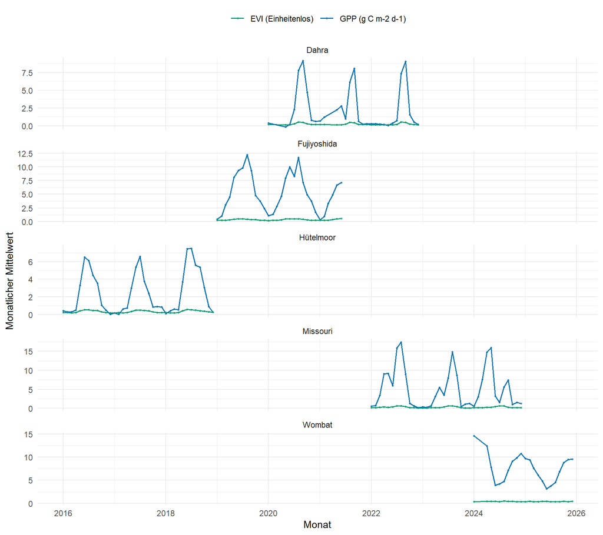

Saisonaler Verlauf des EVI und der FLUXNET-GPP. Beide Serien sind monatliche Mittel je Turm; der Abstand der Achsenskalen macht relative, nicht absolute Verhältnisse sichtbar.

```r
plot_ts <- analysis |>
  mutate(month = as.Date(paste0(month, "-01"))) |>
  pivot_longer(c(GPP, EVI), names_to = "variable", values_to = "value")

ggplot(plot_ts, aes(month, value, colour = variable)) +
  geom_line(linewidth = 0.7) +
  geom_point(size = 0.6, alpha = 0.7) +
  facet_wrap(~site_label, ncol = 1, scales = "free_y") +
  scale_colour_manual(values = c(GPP = "#0072B2", EVI = "#009E73"),
                      labels = c(GPP = "GPP (g C m-2 d-1)", EVI = "EVI (Einheitenlos)")) +
  labs(x = "Monat", y = "Monatlicher Mittelwert", colour = NULL) +
  theme_minimal() +
  theme(legend.position = "top")
```

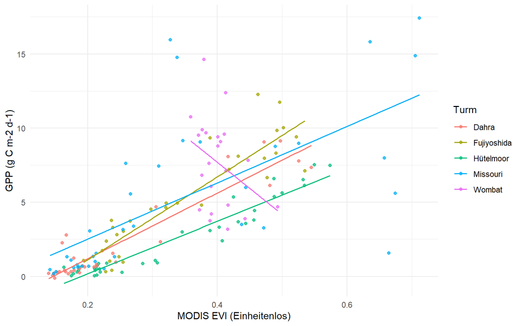

Beziehung zwischen monatlichem EVI und GPP an den fünf Türmen. Jede Farbe bezeichnet einen Turm; die Linien sind Turmspezifische lineare Anpassungen.

```r
ggplot(analysis, aes(EVI, GPP, colour = site_label)) +
  geom_point(alpha = 0.75) +
  geom_smooth(method = "lm", se = FALSE, linewidth = 0.7) +
  labs(x = "MODIS EVI (Einheitenlos)", y = "GPP (g C m-2 d-1)", colour = "Turm") +
  theme_minimal()
```

```r
kable(per_site |> select(site_label, n_months, r_ndvi_gpp, r_evi_gpp), digits = 3,
      caption = "Monatliche Pearson-Korrelationen je Turm",
      col.names = c("Turm", "Gemeinsame Monate", "r(NDVI, GPP)", "r(EVI, GPP)"))
```

Monatliche Pearson-Korrelationen je Turm

| Turm | Gemeinsame Monate | r(NDVI, GPP) | r(EVI, GPP) |
| --- | --- | --- | --- |
| Wombat | 22 | -0.432 | -0.349 |
| Hütelmoor | 36 | 0.929 | 0.961 |
| Fujiyoshida | 30 | 0.905 | 0.905 |
| Dahra | 31 | 0.938 | 0.941 |
| Missouri | 36 | 0.660 | 0.664 |

```r
cat(sprintf("Die gepoolte Pearson-Korrelation beträgt r = %.3f für NDVI und r = %.3f für EVI (n = %d Turm-Monate).",
            pooled_r_ndvi, pooled_r_evi, nrow(analysis)))
```

```
Die gepoolte Pearson-Korrelation beträgt r = 0.643 für NDVI und r = 0.746 für EVI (n = 155 Turm-Monate).
```

Die direkte Antwort ist je Turm unterschiedlich. Die Turmspezifischen Korrelationswerte und die monatlichen Punkte zeigen, ob die beiden saisonalen Verläufe zusammenfallen oder ob einzelne Jahreszeiten abweichen.

## E5. Diskussion

Die gepoolte Beziehung unterstützt die Hypothese einer positiven saisonalen Kopplung, aber nur allgemein und nicht an jedem Turm. Die Korrelation ist nicht kausal: Beide Größen können von Jahreszeit, Temperatur und Wasserversorgung gesteuert werden, ohne dass der Satellitenindex die Ökosystem-GPP direkt misst.

Bei MODIS beträgt die räumliche Auflösung 250 m mit einem ausgewerteten Fenster von etwa 2 × 2 km. Dieses ist deutlich größer als die typischen 100 m bis 1 km des Eddy-Covariance-Footprints. Der Mittelwert kann dadurch Nachbarvegetation oder Bewirtschaftungsflächen enthalten, besonders an heterogenen Standorten wie Wombat oder US-Mo1.

ERA5-Land wird an einem 0.1°-Punkt bzw. Gitterpunkt von ungefähr 9 km Auflösung extrahiert. Dadurch bildet es die lokale Turmumgebung nur grob ab und kann feine Boden- oder Bewässerungsunterschiede nicht erfassen. Temperaturabweichungen können daher erklären, warum die ökologische Beziehung nicht vollständig übereinstimmt, sind aber kein Maß für die lokale Bodenwassersituation am Turm.

Wichtige Einschränkungen sind die nur drei verfügbaren MODIS-Jahre je Turm, die lineare Interpolation von 16-Tage-Kompositen auf tägliche Zeitpunkte und die fehlende Unabhängigkeit monatlicher Zeitreihenwerte. Zusätzlich können Wolken, Ausreiser und das Abholzen bzw. Ernten in einem Jahr die spektralen Werte beeinflussen.

Mit mehr Zeit würde ich die Indizes zu einem jährlichen saisonalen Umfang aggregieren, einen gemeinsamen Überlappungszeitraum aller Türme verwenden und NDVI sowie EVI getrennt nach Vegetationstyp analysieren. Für eine robustere Kausalprüfung könnten Jahresmaxima, saisonale Amplituden und ERA5-Temperatur oder Bodenfeuchte in einem gemischten Modell berücksichtigt werden.

## E6. Daten und Zitationen

- **FLUXNET:** Pastorello et al. (2020), *The FLUXNET2015 dataset and the ONEFlux processing pipeline*, Scientific Data 7, 225. Einzelstandort-Citationen stammen aus `data/snapshots/fluxnet_shuttle_snapshot_20261123T163057.csv` und `tower_sets_block4.csv`.
- **MODIS:** Didan, K. (2021), MOD13Q1 MODIS/Terra Vegetation Indices 16-Day L3 Global 250 m SIN Grid V061, NASA LP DAAC. https://doi.org/10.5067/MODIS/MOD13Q1.061
- **ERA5-Land:** Muñoz-Sabater, J. et al. (2021), ERA5-Land: a state-of-the-art global reanalysis dataset for land applications, *Earth System Science Data* 13, 4349–4383. https://doi.org/10.5194/essd-13-4349-2021
- Die FLUXNET-Datenprodukte wurden von AmeriFlux, ICOS, TERN, OzFlux und weiteren regionalen Netzwerken bereitgestellt und durch ONEFlux standardisiert. Die Download-Snapshot-Citationen werden für die jeweiligen Standorte verwendet.